| title: “Multistate Model” |
| --- |
| author: “Simon Bonner” |
| date: “2016-09-19” |
| output: rmarkdown::html_vignette |
| vignette: > |
| % |
| % |
| % |

## Introduction

Here I compare the runtime and inference for a simple multistate model fit in Program MARK via RMark. The data for this is example was simulated from a multistate model with 35 capture occasions and 5 states. The data generating model incporated time dependent capture and survival probabilities and state specific transition probabilities, and included a total of 88 parametes. The same model was used in the analysis and was fit first to the full data set without truncation and to the truncated data set using the default truncation factor, $k=5$.

## Preliminaries

```r
## Load packages
library(spark)
library(RMark)
library(ggplot2)

## Set path to data set
infile = system.file("extdata", "msdata1000.inp", package = "spark")
```

## Run 1: Full Data

I first fit the model using the full data set.

```r
## 1) Process data
msprocessed.full =
  process.data(RMark::convert.inp(infile), model = "Multistrata")

## 2) Build design data
msddl.full = make.design.data(msprocessed.full,
                               parameters = list(
                                 Psi = list(pim.type = "constant"),
                                 S = list(pim.type = "time"),
                                 p = list(pim.type = "time")
                               ))

## 3) Run model
model.parameters = list(
  S = list(formula =  ~ time),
  p = list(formula =  ~ time),
  Psi = list(formula =  ~ stratum:tostratum - 1)
)

## This is how the model is run via RMark. However, this can take some time and requires Program MARK to be installed, so that the vignette will not pass the CRAN check.
# time.full =
#   system.time(
#     msmodel.full <- mark(
#       msprocessed.full,
#       msddl.full,
#       model.parameters = model.parameters,
#       threads = 4,
#       output = FALSE
#     )
#   )

## Instead, we can load stored output from a previous run.
load(system.file("extdata","msdata1000_output_full.RData",package="spark"))
```

## Run 2: Truncated Data

I now repeat the analysis with truncated data using the default truncation factor, $k=5$.

```r
## Run spark
msdata = spark(infile = infile,
                informat = "mark",
                outformat = "mark")

## Fit model to truncated data
## 1) Process data
msprocessed.trunc =
  process.data(
    msdata,
    model = "Multistrata"
    )

## 2) Build design data
msddl.trunc = make.design.data(msprocessed.trunc,
                                parameters = list(
                                  Psi = list(pim.type = "constant"),
                                  S = list(pim.type = "time"),
                                  p = list(pim.type = "time")
                                ))

## 3) Fit model

## This is how the model is run via RMark. However, this can take some time and requires Program MARK to be installed, so that the vignette will not pass the CRAN check.
# time.trunc =
#   system.time(
#     msmodel.trunc <- mark(
#       msprocessed.trunc,
#       msddl.trunc,
#       model.parameters = model.parameters,
#       threads = 4,
#       output = FALSE
#     )
#   )

## Instead, we can load stored output from a previous run.
load(system.file("extdata","msdata1000_output_trunc.RData",package="spark"))
```

## Results

### Inference

The following plots compare the point estimates and 95% confidence intervals for the three groups of parameters in the model. As you can see, inference based on the truncated data is almost identical to inference based on the full data set.

#### Survival Probabilities

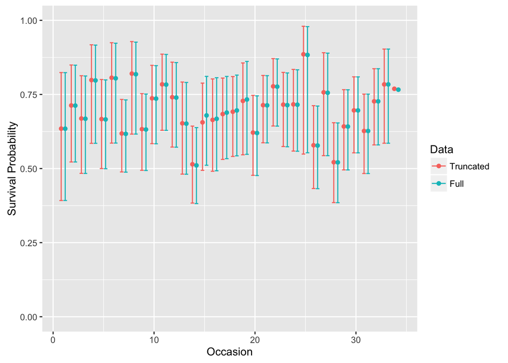

#### Capture Probabilities

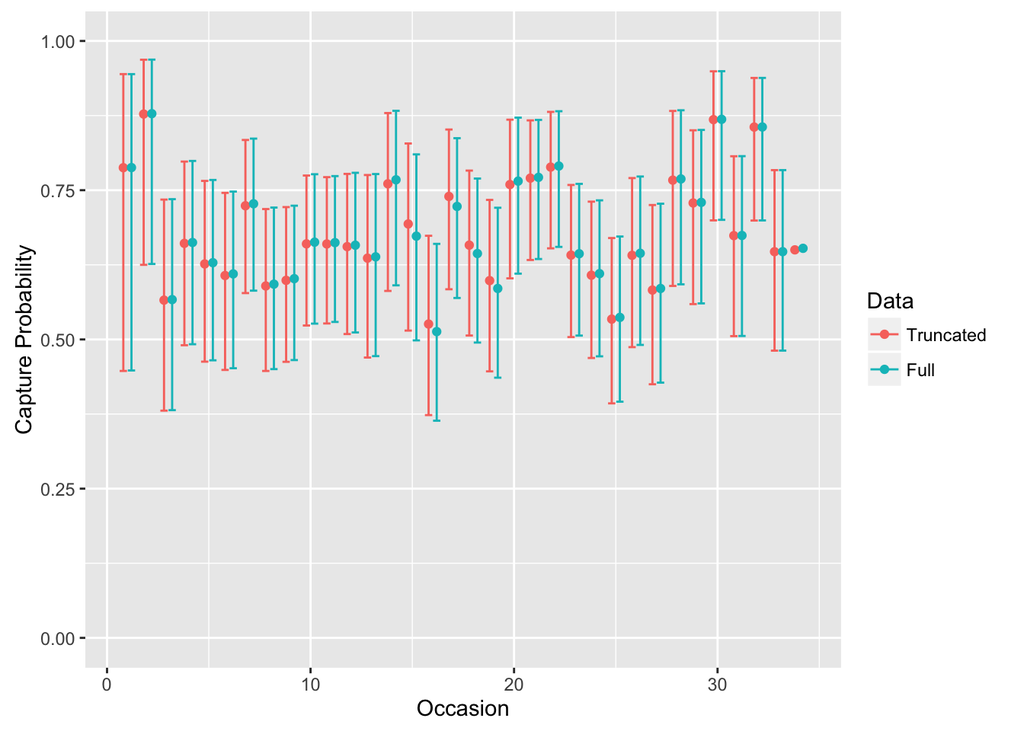

#### Transition Probabilities

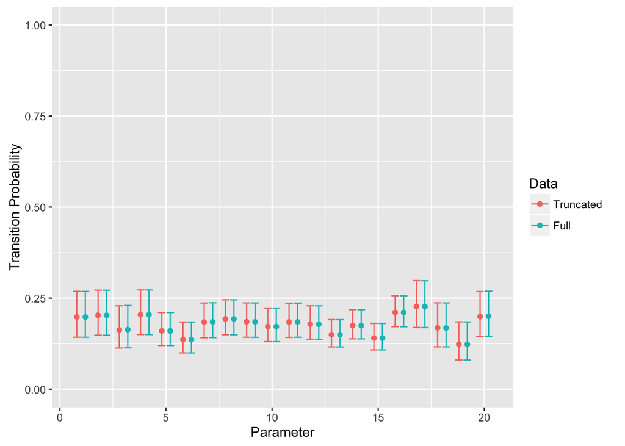